# Insurance premium prediction

Project by: NAMISHA TARI

```python
#import libraries
import pandas as pd
import numpy as np
import matplotlib.pyplot as plt
%matplotlib inline
import seaborn as sns
import sys#system-specific parameters and functions
```

```python
#reading the dataset
df=pd.read_csv("C:\\Users\\NAMISHA T\\OneDrive\\Desktop\\project\\insurance.csv")
```

```python
print(df)
```

```
      age     sex   bmi  children smoker     region  expenses
0      19  female  27.9         0    yes  southwest  16884.92
1      18    male  33.8         1     no  southeast   1725.55
2      28    male  33.0         3     no  southeast   4449.46
3      33    male  22.7         0     no  northwest  21984.47
4      32    male  28.9         0     no  northwest   3866.86
...   ...     ...   ...       ...    ...        ...       ...
1333   50    male  31.0         3     no  northwest  10600.55
1334   18  female  31.9         0     no  northeast   2205.98
1335   18  female  36.9         0     no  southeast   1629.83
1336   21  female  25.8         0     no  southwest   2007.95
1337   61  female  29.1         0    yes  northwest  29141.36

[1338 rows x 7 columns]
```

```python
#to see the dimension of the dataframe
df.shape
```

```
(1338, 7)
```

```python
#top 5 rowns
df.head()
```

|  | age | sex | bmi | children | smoker | region | expenses |
| --- | --- | --- | --- | --- | --- | --- | --- |
| 0 | 19 | female | 27.9 | 0 | yes | southwest | 16884.92 |
| 1 | 18 | male | 33.8 | 1 | no | southeast | 1725.55 |
| 2 | 28 | male | 33.0 | 3 | no | southeast | 4449.46 |
| 3 | 33 | male | 22.7 | 0 | no | northwest | 21984.47 |
| 4 | 32 | male | 28.9 | 0 | no | northwest | 3866.86 |

```python
# to check for missing  values
df.isnull().sum()
```

```
age         0
sex         0
bmi         0
children    0
smoker      0
region      0
expenses    0
dtype: int64
```

## UNIVARIATE ANALYSIS

```python
def cool_countplot(data=None, x=None, y=None, hue=None, text_size=10):
    ax = sns.countplot(data=data, x=x, hue=hue)
    for p in ax.patches:
        ax.annotate(text=str(int(p.get_height())) + ' (' + '{:.0%}'.format(p.get_height()/data.shape[0]) + ')',
                       xy=(p.get_x()+p.get_width()/2, p.get_height()/2), ha='center', color='black', size=text_size,s="Message")
    return ax
```

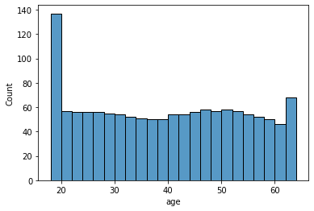

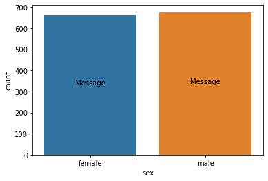

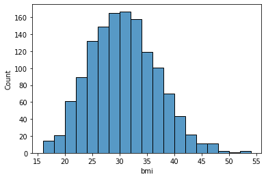

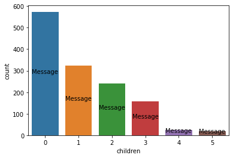

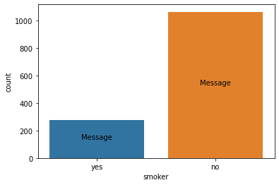

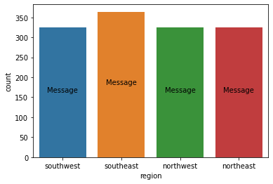

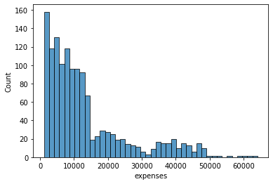

```python
for col in df.drop('expenses',axis=1).columns:
    if col in ['age', 'bmi']:
        sns.histplot(data=df, x=col, binwidth=2)
    else:
        cool_countplot(data=df, x=col)
    plt.show()

sns.histplot(data=df, x='expenses', binwidth=1500)
plt.show()
```

## MULTIVARIATE ANALYSIS

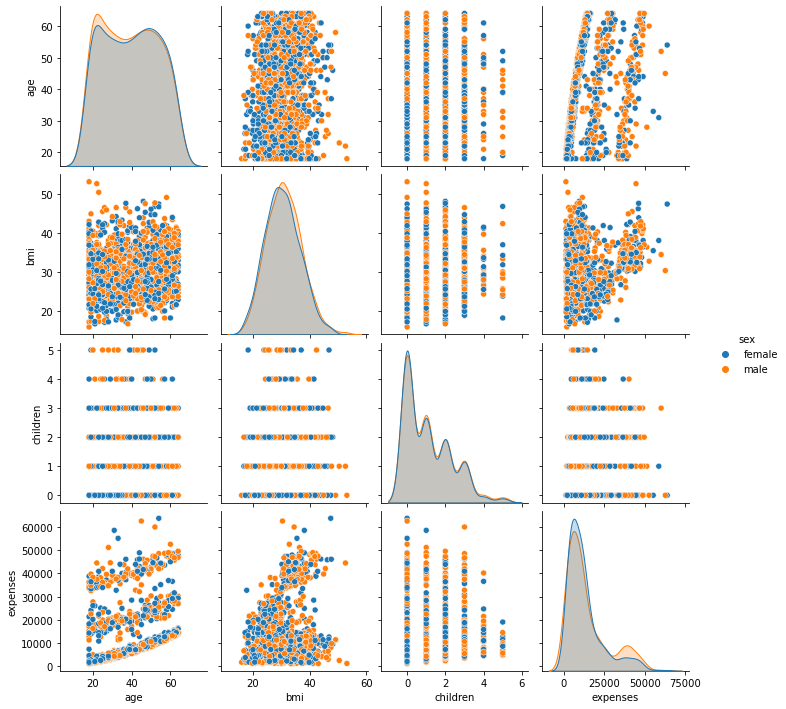

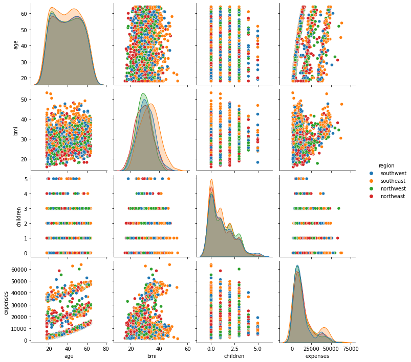

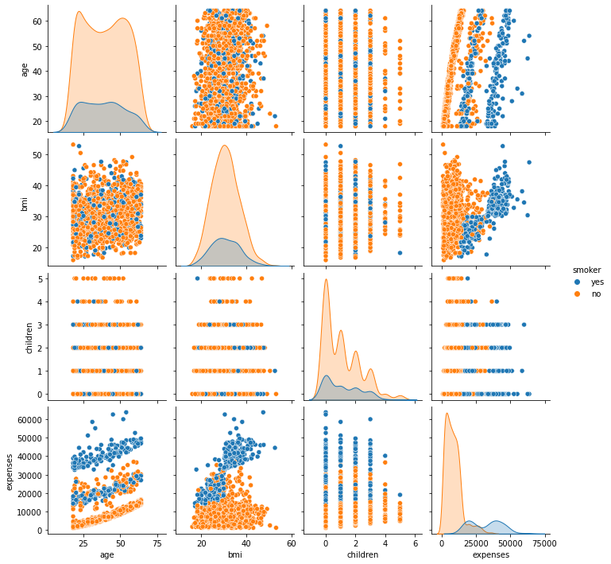

```python
for category in ['sex', 'region', 'smoker']:
    sns.pairplot(df, hue=category, diag_kind='kde')
```

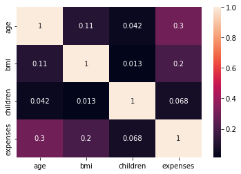

```python
#To find correlation between each variable
df.corr()
corrMatrix = df.corr()
sns.heatmap(corrMatrix,annot=True)
```

```python
df
```

|  | age | sex | bmi | children | smoker | region | expenses |
| --- | --- | --- | --- | --- | --- | --- | --- |
| 0 | 19 | female | 27.9 | 0 | yes | southwest | 16884.92 |
| 1 | 18 | male | 33.8 | 1 | no | southeast | 1725.55 |
| 2 | 28 | male | 33.0 | 3 | no | southeast | 4449.46 |
| 3 | 33 | male | 22.7 | 0 | no | northwest | 21984.47 |
| 4 | 32 | male | 28.9 | 0 | no | northwest | 3866.86 |
| ... | ... | ... | ... | ... | ... | ... | ... |
| 1333 | 50 | male | 31.0 | 3 | no | northwest | 10600.55 |
| 1334 | 18 | female | 31.9 | 0 | no | northeast | 2205.98 |
| 1335 | 18 | female | 36.9 | 0 | no | southeast | 1629.83 |
| 1336 | 21 | female | 25.8 | 0 | no | southwest | 2007.95 |
| 1337 | 61 | female | 29.1 | 0 | yes | northwest | 29141.36 |

1338 rows × 7 columns

```python
# replacing values
df['sex'].replace(['male', 'female'],
                        [0, 1], inplace=True)
df['smoker'].replace(['yes', 'no'],
                        [0, 1], inplace=True)
df['region'].replace(['southwest', 'southeast','northwest','northeast'],
                        [1,2,3,4], inplace=True)
```

```python
df
```

|  | age | sex | bmi | children | smoker | region | expenses |
| --- | --- | --- | --- | --- | --- | --- | --- |
| 0 | 19 | 1 | 27.9 | 0 | 0 | 1 | 16884.92 |
| 1 | 18 | 0 | 33.8 | 1 | 1 | 2 | 1725.55 |
| 2 | 28 | 0 | 33.0 | 3 | 1 | 2 | 4449.46 |
| 3 | 33 | 0 | 22.7 | 0 | 1 | 3 | 21984.47 |
| 4 | 32 | 0 | 28.9 | 0 | 1 | 3 | 3866.86 |
| ... | ... | ... | ... | ... | ... | ... | ... |
| 1333 | 50 | 0 | 31.0 | 3 | 1 | 3 | 10600.55 |
| 1334 | 18 | 1 | 31.9 | 0 | 1 | 4 | 2205.98 |
| 1335 | 18 | 1 | 36.9 | 0 | 1 | 2 | 1629.83 |
| 1336 | 21 | 1 | 25.8 | 0 | 1 | 1 | 2007.95 |
| 1337 | 61 | 1 | 29.1 | 0 | 0 | 3 | 29141.36 |

1338 rows × 7 columns

## MODELLING

Splitting the dataset into train and test data

```python
#dividing the datset into dependent and independent
X=df.iloc[:,:-1] # independent feature
Y=df.iloc[:,-1] #dependent feature
```

```python
X.head()
```

|  | age | sex | bmi | children | smoker | region |
| --- | --- | --- | --- | --- | --- | --- |
| 0 | 19 | 1 | 27.9 | 0 | 0 | 1 |
| 1 | 18 | 0 | 33.8 | 1 | 1 | 2 |
| 2 | 28 | 0 | 33.0 | 3 | 1 | 2 |
| 3 | 33 | 0 | 22.7 | 0 | 1 | 3 |
| 4 | 32 | 0 | 28.9 | 0 | 1 | 3 |

```python
Y.head()
```

```
0    16884.92
1     1725.55
2     4449.46
3    21984.47
4     3866.86
Name: expenses, dtype: float64
```

```python
from sklearn.model_selection import train_test_split
train_X,test_X,train_Y,test_Y=train_test_split(X,Y,test_size=0.2,random_state=0)
#test_size - represent the proportion of the dataset to include in the train split.
```

## multiple linear regression

```python
# import LinearRegression from sklearn
from sklearn.linear_model import LinearRegression
# Representing LinearRegression as lr(Creating LinearRegression Object)
lr = LinearRegression()
#You don't need to specify an object to save the result because 'lr' will take the results of the fitted model.
lr.fit(train_X, train_Y)
```

```
LinearRegression()
```

```python
# Making predictions on the testing set
y_pred = lr.predict(test_X)
```

## Model Evaluation

Let's have a visuals representation of our actaual and predicted values

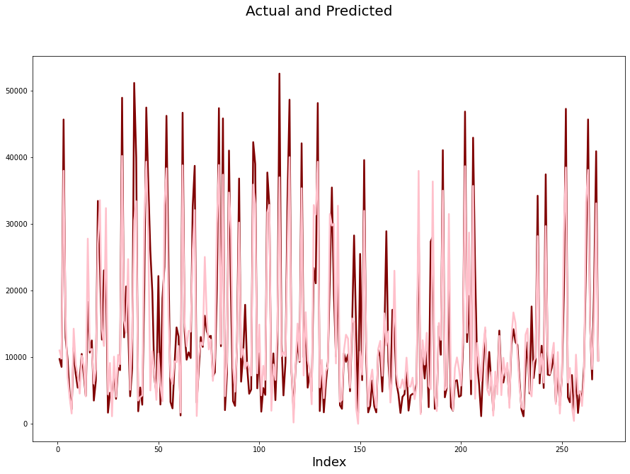

```python
# Actual vs Predicted
plt.figure(figsize = (15,10))

c = [i for i in range(1,len(test_X.index)+1,1)] # generating index

plt.plot(c,test_Y, color="maroon", linewidth=2.5, linestyle="-")
plt.plot(c,y_pred, color="pink", linewidth=2.5, linestyle="-")
plt.suptitle('Actual and Predicted', fontsize=20)
plt.xlabel('Index', fontsize=18)
```

Evaluating model accuracy

one of a way to evaluate the performance of a linear regresion model rather than plotting it, using evalution metrices.The essential step in any machine learning model is to evaluate the accuracy of the model. The Mean Squared Error, Mean absolute error, and R-Squared or Coefficient of determination metrics are used to evaluate the performance of the model in regression analysis.

```python
from sklearn.metrics import mean_squared_error, r2_score,mean_absolute_error
mse = mean_squared_error(test_Y, y_pred)
r_squared = r2_score(test_Y, y_pred)
print('Mean_Squared_Error :' ,mse)
print('r_square_value :',r_squared)
print("Mean Absolute Error : ",mean_absolute_error(y_pred,test_Y))
```

```
Mean_Squared_Error : 31841055.888540454
r_square_value : 0.7999053396503136
Mean Absolute Error :  3930.2173746197864
```

our model is 80% accurate.